# An anti-inflammatory response of an organic food intervention treatment by reducing pesticide exposures in children of Cyprus: a cluster-randomized crossover trial - Sensitivity Analysis Type 1 - part 1

## Sensitivity analysis Type 1 - part 1

Sensitivity analysis was carried out to assess if there was any influence of extreme values on the observed associations between exposure and outcome. CRP raw measurements higher than the 99th percentile were excluded from the analysis and all models were rerun.

## Urinary data

Percentage of samples below the LOD and LOQ (Units Creatinine:g/l, 6CN:ug/l, 3PBA:ug/l, CRP:ng/L)

Below LOQ (only for the pesticides and only for the whole period)

6CN (<0.226), 3PBA (<0.146)

- 6CN: 81.85
- 3PBA: 25.76

Below LOD

Creatinine (<0.25), 6CN (<0.075), 3PBA (<0.049), CRP (<62.5)

- Overall
- Creatinine: 0
- CRP: 0
- 6CN: 71.55
- 3PBA: 23.07
- Organic phase
- CRP: 0
- 6CN: 76.85
- 3PBA: 31.26
- Conventional phase (including the baseline)
- CRP: 0
- 6CN: 66.44
- 3PBA: 15.17

## Biomarkers descriptives

### Table 1 - Percentage of 6-CN values below and above LOD by sample by group

Percentage of 6-CN values below and above LOD for 149 participants by group and by sample

|  | 1:1 | 2:1 | 3:1 | 4:1 | 5:1 | 6:1 | 1:2 | 2:2 | 3:2 | 4:2 | 5:2 | 6:2 |
| --- | --- | --- | --- | --- | --- | --- | --- | --- | --- | --- | --- | --- |
| n | 43 | 42 | 40 | 37 | 37 | 37 | 106 | 106 | 106 | 106 | 98 | 96 |
| cnlod = Above LOD (%) | 16 (37.2) | 14 (33.3) | 8 (20.0) | 10 (27.0) | 9 (24.3) | 19 (51.4) | 40 (37.7) | 32 (30.2) | 30 (28.3) | 24 (22.6) | 22 (22.4) | 19 (19.8) |

### Table 2 - Percentiles of CRP, 6CN, 3PBA (overall)

- Note: the tables are based on the imputed data
- Units: CRP:ng/L, 3PBA:ng/L

Quantiles of the raw concentrations

|  | 0% | 5% | 25% | 50% | 75% | 95% | 100% |
| --- | --- | --- | --- | --- | --- | --- | --- |
| pb_q | 7.87 | 73.53 | 268.69 | 1319.00 | 3354.25 | 12763.55 | 71967.00 |
| crp_q | 111.39 | 230.93 | 321.86 | 388.28 | 497.80 | 932.44 | 3773.77 |
| cr_q | 0.30 | 0.51 | 0.85 | 1.14 | 1.48 | 2.06 | 2.88 |

- Units: crp:ng/L Cr, 3PBA:ng/L

Quantiles of the creatinine adjusted concentrations

|  | 0% | 5% | 25% | 50% | 75% | 95% | 100% |
| --- | --- | --- | --- | --- | --- | --- | --- |
| crpb_q | 4.77 | 57.11 | 260.17 | 1137.42 | 3226.54 | 12452.40 | 59515.28 |
| crp_q_adj | 83.24 | 159.78 | 249.21 | 358.71 | 522.75 | 1060.06 | 4550.95 |

### Table 2 A - Percentiles of CRP during the organic treatment

- Note: the tables are based on the imputed data
- Units: CRP:ng/L

Quantiles of the raw concentrations during the organic treatment

|  | 0% | 5% | 25% | 50% | 75% | 95% | 100% |
| --- | --- | --- | --- | --- | --- | --- | --- |
| crp_qorg | 114.87 | 214.48 | 311.79 | 383.17 | 498.98 | 934.17 | 3020.41 |

- Units: CRP:ng/L

Quantiles of the creatinine adjusted concentrations during the organic treatment

|  | 0% | 5% | 25% | 50% | 75% | 95% | 100% |
| --- | --- | --- | --- | --- | --- | --- | --- |
| crp_qorg_adj | 83.24 | 147.7 | 242.05 | 349.42 | 517.18 | 994.18 | 3640.26 |

### Table 2 B - Percentiles of CRP during the conventional treatment

- Note: the tables are based on the imputed data
- Units: crp:ng/L

Quantiles of the raw concentrations during the conventional treatment

|  | 0% | 5% | 25% | 50% | 75% | 95% | 100% |
| --- | --- | --- | --- | --- | --- | --- | --- |
| crp_qcon | 111.39 | 256.95 | 335.72 | 390.21 | 496.94 | 930.77 | 3773.77 |

- Units: crp:ng/L Cr

Quantiles of the creatinine adjusted concentrations during the conventional treatment

|  | 0% | 5% | 25% | 50% | 75% | 95% | 100% |
| --- | --- | --- | --- | --- | --- | --- | --- |
| crp_qcon_adj | 91.82 | 171.76 | 261.72 | 371.82 | 526.63 | 1176.89 | 4550.95 |

### Table 3 - Summary tables of pesticide metabolites, creatinine and CRP

- Note: the tables are based on the imputed data
- Units: ng/L for CRP, 3-PBA, g/L for creatinine

Summary table of meas_saurements - non-creatinine adjusted

|  | Overall |
| --- | --- |
| n | 854 |
| pb1000 (median [IQR]) | 1319.00 [268.69, 3354.25] |
| crp (median [IQR]) | 388.28 [321.86, 497.80] |
| cr (median [IQR]) | 1.14 [0.85, 1.48] |

- Units: ng/L for CRP, 3-PBA, g/L for creatinine

Summary table of meas_saurements -Creatinine adjusted

|  | Overall |
| --- | --- |
| n | 854 |
| adj_pb1000 (mean (SD)) | 3009.12 (5274.40) |
| adj_crp (mean (SD)) | 464.45 (408.75) |
| cr (median [IQR]) | 1.14 [0.85, 1.48] |

### Table 3 A - Summary tables of pesticide metabolites, creatinine and CRP by treatment

- Note: the tables are based on the imputed data
- Units: ng/L for CRP, 3-PBA, g/L for creatinine

Summary table of meas_saurements per phase - non-creatinine adjusted

|  | Conventional | Organic | p | test |
| --- | --- | --- | --- | --- |
| n | 435 | 419 |  |  |
| pb1000 (median [IQR]) | 2151.00 [714.50, 5575.00] | 659.00 [198.67, 1758.50] | <0.001 | nonnorm |
| crp (median [IQR]) | 390.21 [335.72, 496.94] | 383.17 [311.79, 498.98] | 0.275 | nonnorm |
| cr (median [IQR]) | 1.11 [0.83, 1.42] | 1.17 [0.87, 1.57] | 0.029 | nonnorm |

- Units: ng/L for CRP, 3-PBA, g/L for creatinine

Summary table of meas_saurements per phase - Creatinine adjusted

|  | Conventional | Organic | p | test |
| --- | --- | --- | --- | --- |
| n | 435 | 419 |  |  |
| adj_pb1000 (median [IQR]) | 2079.01 [682.79, 5156.90] | 572.50 [163.44, 1651.14] | <0.001 | nonnorm |
| adj_crp (median [IQR]) | 371.82 [261.72, 526.63] | 349.42 [242.05, 517.18] | 0.031 | nonnorm |
| cr (median [IQR]) | 1.11 [0.83, 1.42] | 1.17 [0.87, 1.57] | 0.029 | nonnorm |

## Boxplots

The boxplots are included in the script as additional material to what is included in the manuscript. The boxplots are not included in the manuscript. In the boxplots of CRP the upper 5% of values have been excluded to make the plots easier to read. Imputed data are included.

```
## [1] 16
```

```
## [1] 16
```

```
## [1] TRUE
```

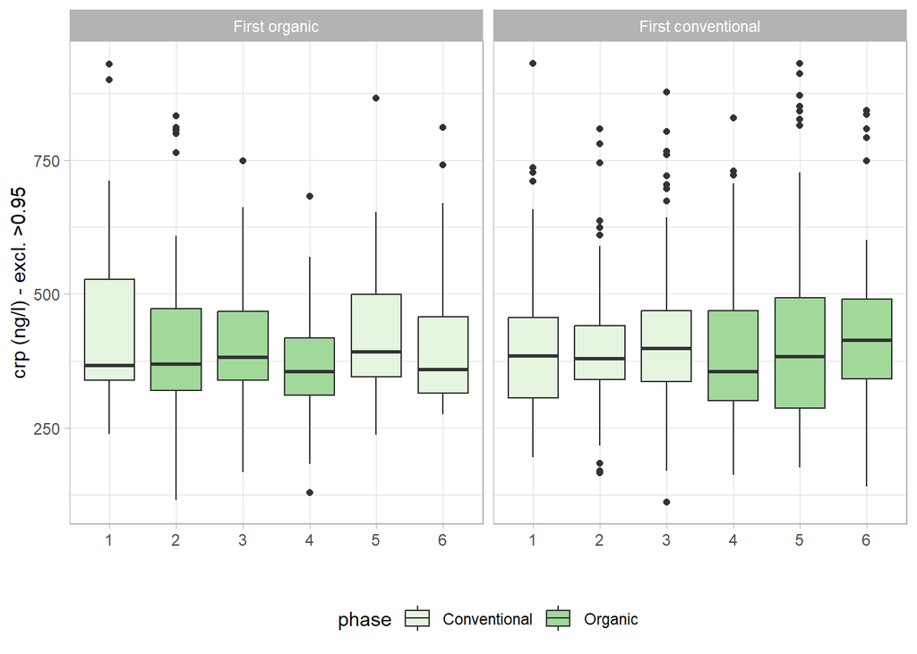

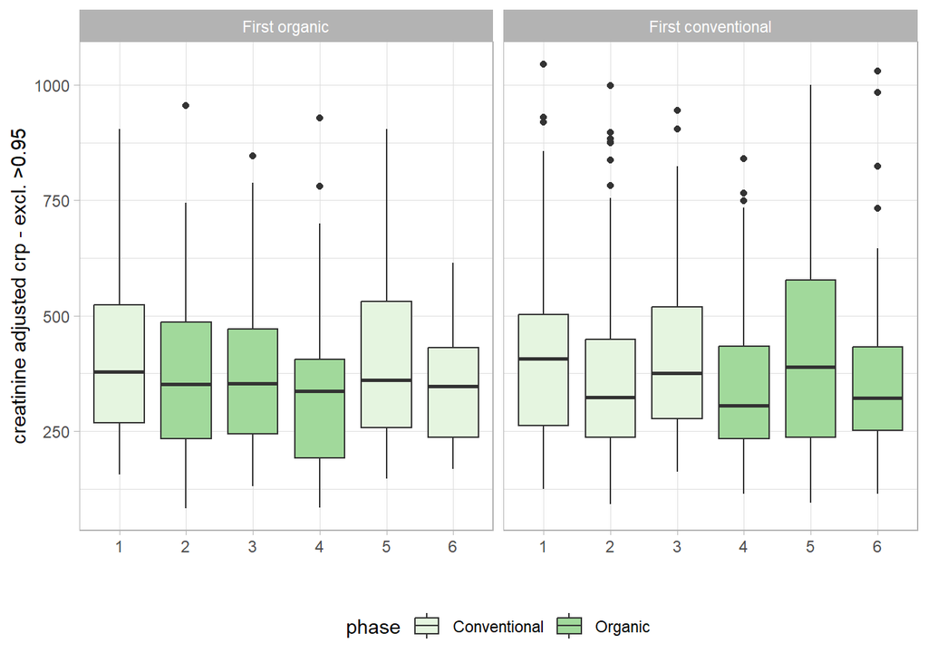

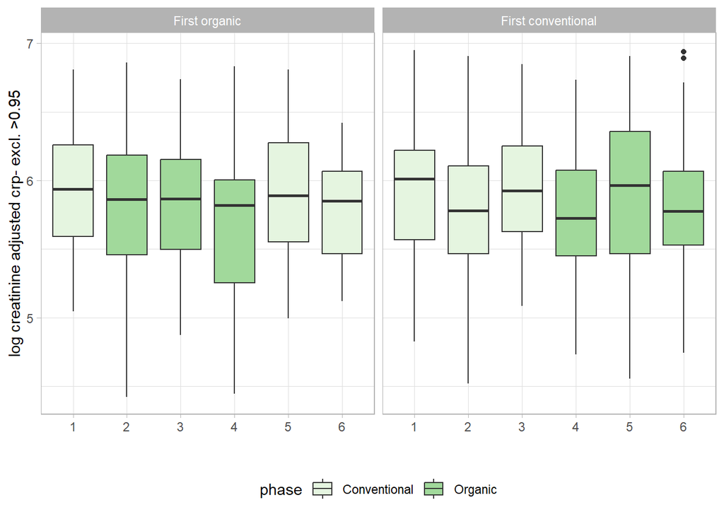

```r
dir_path<-getwd() # working dir to be used in making the new file bel
analysis_rds_dir<-paste0(dir_path, "/produced_data", sep="")
if(!dir.exists(analysis_rds_dir)) dir.create(analysis_rds_dir)

saveRDS(meas_sa1, file.path(analysis_rds_dir, "meas_sa1.rds"))
```